# Exploratory Data Analysis

Derex Wangmang

## Loading Packages and Data

```r
library(tidyverse)
library(ggcorrplot)

load("data/processed/intermediate_seoul_bike_data.rda")
```

## Plots

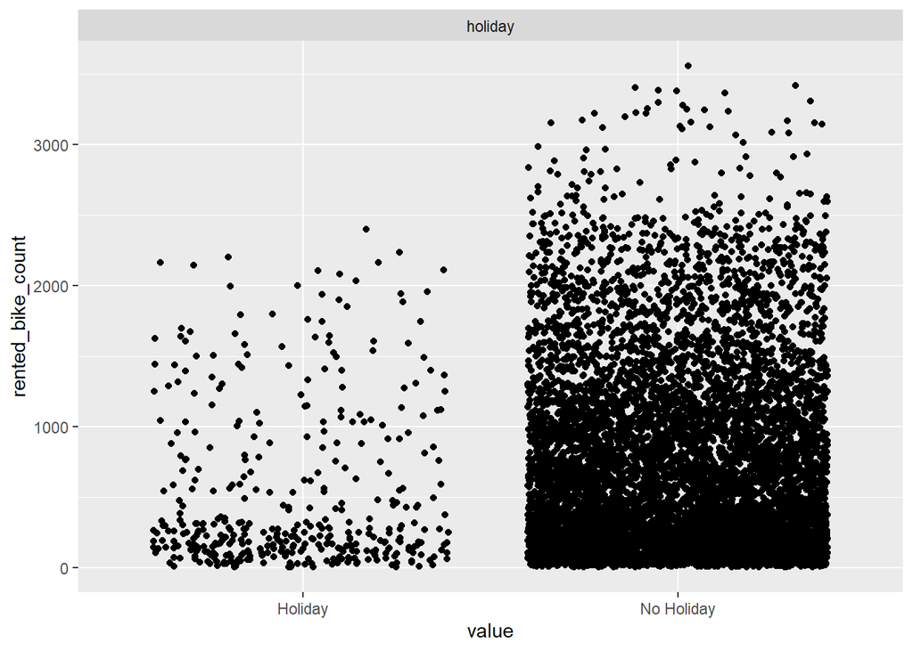

```r
bike %>%
  select(where(is.factor), rented_bike_count) %>%
  gather(-rented_bike_count, key = "var", value = "value") %>%
  ggplot(aes(x = value, y = rented_bike_count)) +
  geom_jitter() +
  facet_wrap(~ var, scales = "free")
```

There is only one categorical variable in the dataset, the holiday. The holiday portion of the graph is much sparser, as expected, as the number of non-holidays far outnumber the number of holidays.

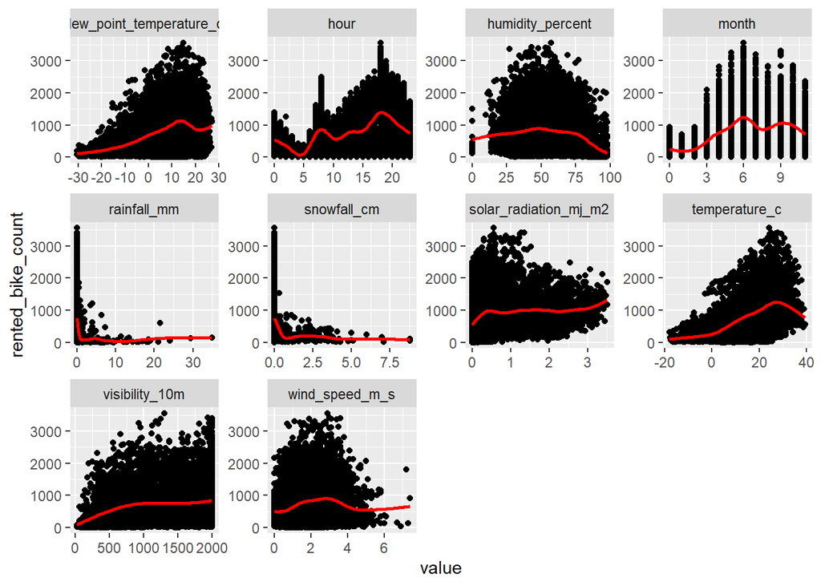

```r
bike %>%
  select(where(is.numeric)) %>%
  gather(-rented_bike_count, key = "var", value = "value") %>%
  ggplot(aes(x = value, y = rented_bike_count)) +
  geom_point() +
  geom_smooth(se = F, color = "red") +
  facet_wrap(~ var, scales = "free")
```

Selecting all the numeric variables and plotting the target variable against them provides an overview of the distributions in the dataset. While informative, the graphs tend to be difficult to read. Thus, I picked out specific ones to examine closer below.

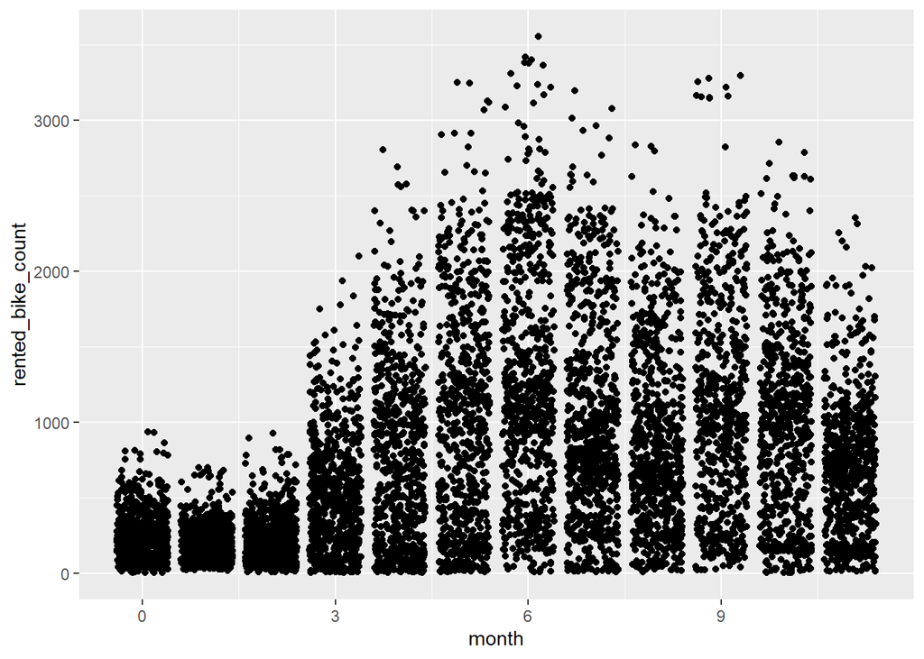

```r
ggplot(bike, aes(month, rented_bike_count)) +
  geom_jitter()
```

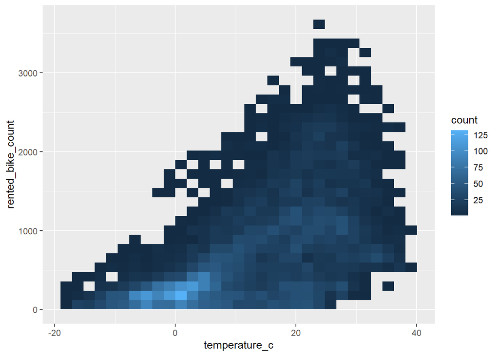

```r
ggplot(bike, aes(temperature_c, rented_bike_count)) +
  geom_bin2d()
```

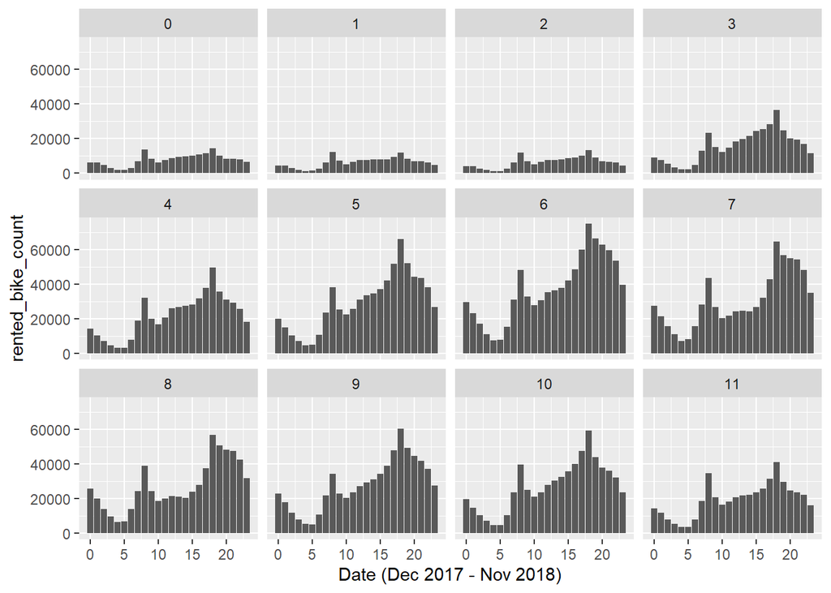

```r
ggplot(bike, aes(hour, rented_bike_count)) +
  geom_col() +
  facet_wrap(~ month) +
  labs(x = "Date (Dec 2017 - Nov 2018)")
```

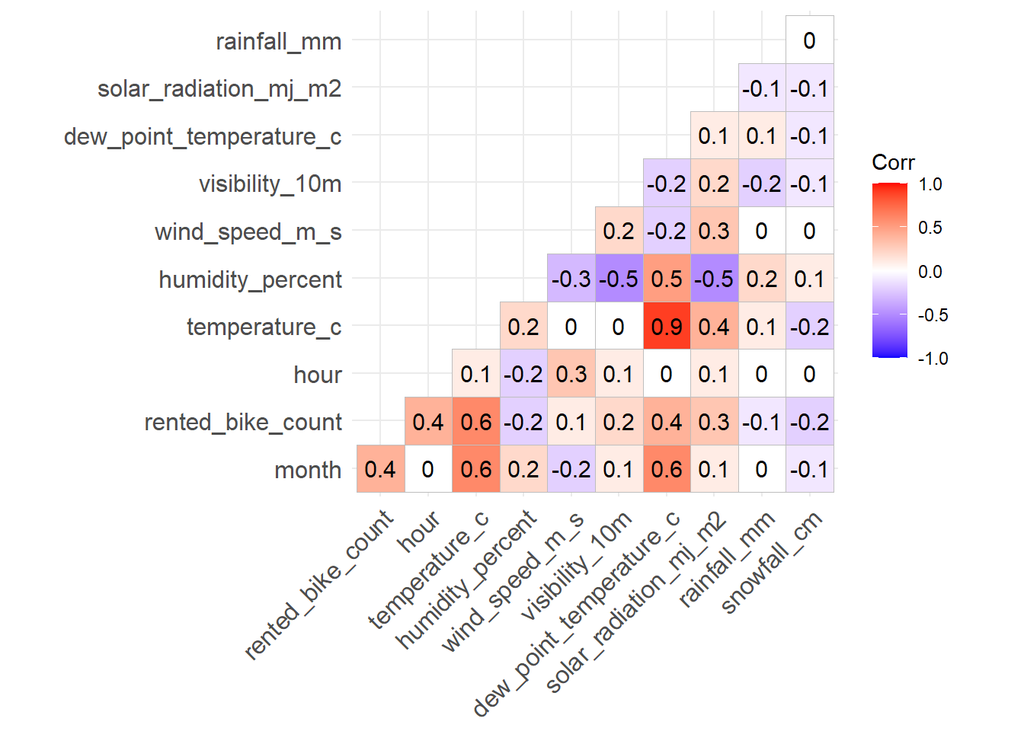

```r
corr <- round(cor(bike %>% select(where(is.numeric))), 1)
ggcorrplot(corr, type = "lower", lab = T)
```

The Pearson Correlation plot indicated that there are two features strongly correlated with each other: the dew point temperature and the temperature.

```r
fit <- lm(rented_bike_count ~ ., bike)
car::vif(fit)
```

```
##                   month                    hour           temperature_c
##                1.665685                1.181179               88.295453
##        humidity_percent          wind_speed_m_s          visibility_10m
##               20.205397                1.295215                1.640993
## dew_point_temperature_c   solar_radiation_mj_m2             rainfall_mm
##              116.471474                2.012877                1.084470
##             snowfall_cm                 holiday
##                1.097139                1.008544
```

The collinearity is confirmed by the variance inflation factor.

```r
fit2 <- lm(rented_bike_count ~ . - dew_point_temperature_c, bike)
car::vif(fit2)
```

```
##                 month                  hour         temperature_c
##              1.665589              1.178699              2.166928
##      humidity_percent        wind_speed_m_s        visibility_10m
##              2.562210              1.293253              1.629828
## solar_radiation_mj_m2           rainfall_mm           snowfall_cm
##              1.912811              1.071168              1.092256
##               holiday
##              1.008526
```

Removing `dew_point_temperature_c` led to a large reduction in the variance inflation factor.

```r
bike <- bike %>%
  select(-dew_point_temperature_c)
save(bike, file = "data/processed/seoul_bike_data.rda")
```

Thus, I removed the variable from the processed dataset and saved the updated dataset for future use.

## Rental Bike Count Distribution

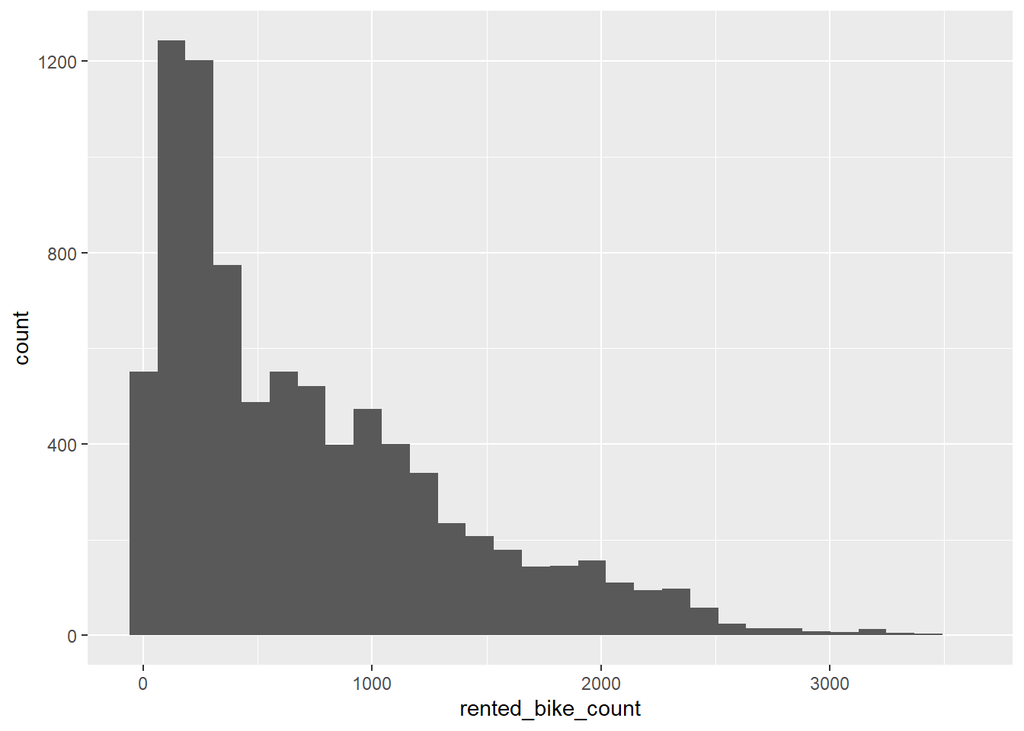

```r
ggplot(bike, aes(rented_bike_count)) +
  geom_histogram()
```

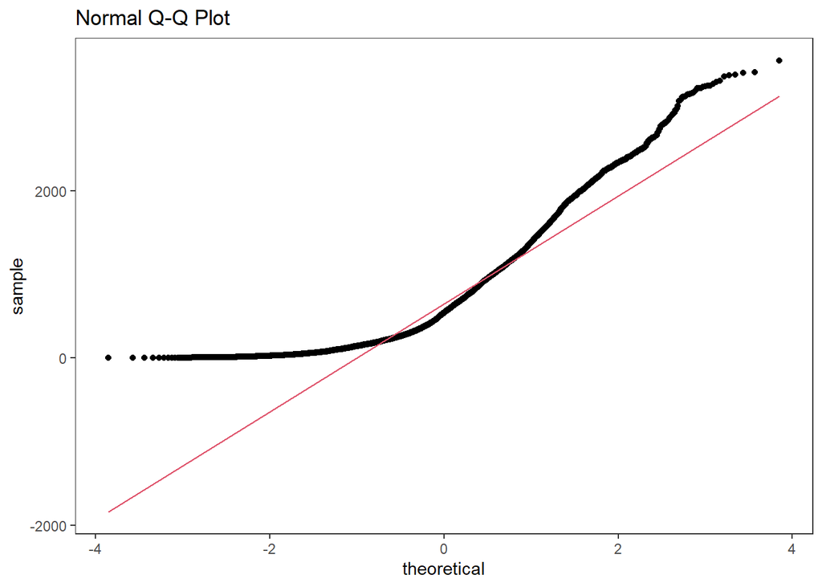

```r
ggplot(bike, aes(sample = rented_bike_count)) +
  stat_qq() +
  stat_qq_line(color = 2) +
  labs(title = "Normal Q-Q Plot") +
  theme_bw() +
  theme(panel.grid = element_blank())
```

This Q-Q plot confirms that the count is non-normal.

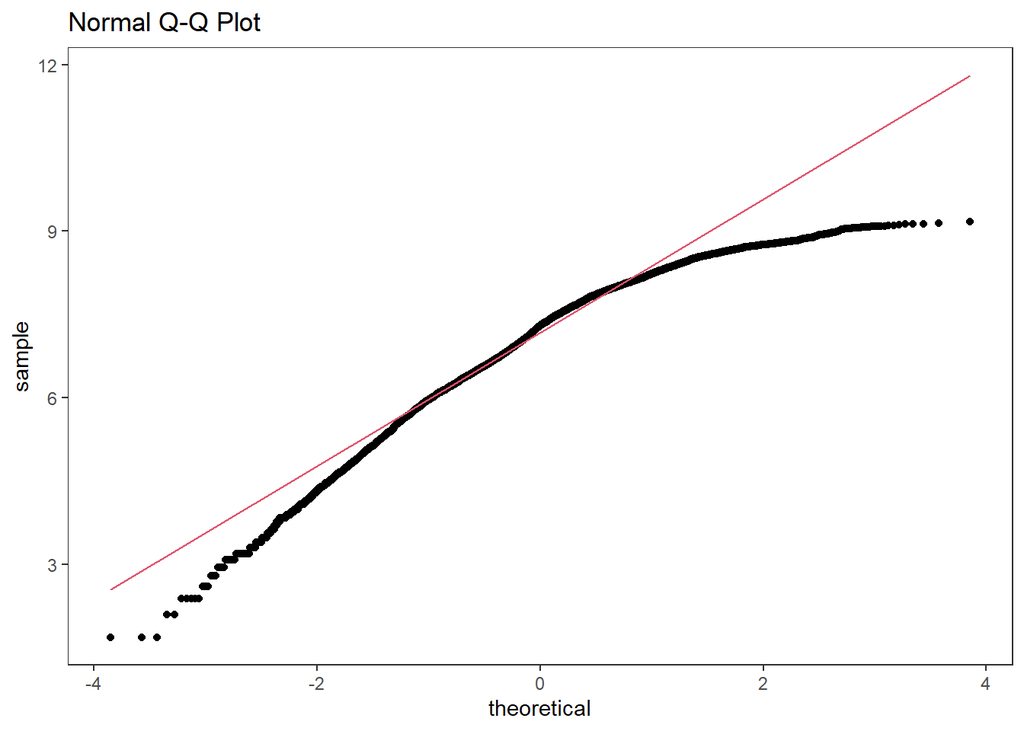

```r
bike %>%
  mutate(rented_bike_count = log(rented_bike_count) + 1) %>%
  ggplot(aes(sample = rented_bike_count)) +
  stat_qq() +
  stat_qq_line(color = 2) +
  labs(title = "Normal Q-Q Plot") +
  theme_bw() +
  theme(panel.grid = element_blank())
```

A log transformation fails to achieve normality. If later models have assumptions of normality, `rented_bike_count` should be transformed differently.